# 1. Projet-7 Nettoyage & Analyse Exploratoire

```python
import mlflow
import gc
from hyperopt import hp
from hyperopt import tpe
from hyperopt import fmin
from hyperopt import space_eval, STATUS_OK

from imblearn.over_sampling import SMOTE
from imblearn.under_sampling import RandomUnderSampler

import lightgbm as lgb
import lime
from lime import lime_tabular

import os

import matplotlib as mpl
%matplotlib inline
import matplotlib.pyplot as plt
import missingno as msno
import numpy as np
import pandas as pd
import pickle
import random
import re
import seaborn as sns
import shap

import sklearn
from sklearn.dummy import DummyClassifier
from sklearn.impute import SimpleImputer
from sklearn.linear_model import LogisticRegression

from sklearn import preprocessing
from sklearn.pipeline import Pipeline
from sklearn.preprocessing import MinMaxScaler
from sklearn.preprocessing import LabelEncoder

from sklearn.metrics import accuracy_score
from sklearn.metrics import roc_auc_score
from sklearn.metrics import roc_curve
from sklearn.metrics import auc
from sklearn.metrics import precision_score, recall_score, f1_score, confusion_matrix

from sklearn.model_selection import cross_validate
from sklearn.model_selection import cross_val_predict
from sklearn.model_selection import GridSearchCV
from sklearn.model_selection import KFold
from sklearn.model_selection import StratifiedKFold
from sklearn.model_selection import train_test_split

import time

# Suppress warnings
import warnings
warnings.filterwarnings('ignore')
```

```
Using `tqdm.autonotebook.tqdm` in notebook mode. Use `tqdm.tqdm` instead to force console mode (e.g. in jupyter console)
```

```python
# # numpy and pandas for data manipulation
# import numpy as np
# import pandas as pd

# # sklearn preprocessing for dealing with categorical variables
# from sklearn.preprocessing import LabelEncoder

# # File system manangement
# import os

# # Suppress warnings
# import warnings
# warnings.filterwarnings('ignore')

# # matplotlib and seaborn for plotting
# import matplotlib.pyplot as plt
# import seaborn as sns
```

```python
dico_pd_option = {
    'display.max_rows': 400,
    'display.max_column': 200,
    'display.width': 300,
    'display.precision': 4,
    'display.max_colwidth': 1000,
    'mode.chained_assignment': None
}
for cle, val in dico_pd_option.items():
    pd.set_option(cle, val)
```

## Les fonctions

```python
def get_missing_values(df_work, pourcentage, affiche_heatmap):
    # 1. Nombre de valeurs manquantes totales
    nb_nan_tot = df_work.isna().sum().sum()
    nb_donnees_tot = np.product(df_work.shape)
    pourc_nan_tot = round((nb_nan_tot / nb_donnees_tot) * 100, 2)
    print(
        f'Valeurs manquantes :{nb_nan_tot} NaN pour\
        {nb_donnees_tot} données ({pourc_nan_tot} %)')
    if pourcentage:
        print("-------------------------------------------------------------")
        print("Nombre et pourcentage de valeurs manquantes par variable\n")
        # 2. Visualisation du nombre et du pourcentage de valeurs manquantes
        # par variable
        values = df_work.isnull().sum()
        percentage = 100 * values / len(df_work)
        table = pd.concat([values, percentage.round(2)], axis=1)
        table.columns = [
            'Nombres de valeurs manquantes',
            '% de valeurs manquantes']
        display(table[table['Nombres de valeurs manquantes'] != 0]
                .sort_values('% de valeurs manquantes', ascending=False)
                .style.background_gradient('seismic'))
    if affiche_heatmap:
        print("-------------------------------------------------------------")
        print("Heatmap de visualisation des valeurs manquantes")
        # 3. Heatmap de visualisation des valeurs manquantes
        plt.figure(figsize=(20, 10))
        sns.heatmap(df_work.isna(), cbar=False)
        plt.show()
```

```python
def description_variables(dataframe, type_var='all'):
    df_taille = dataframe.shape[0]

    if type_var == 'num':
        desc_var = dataframe.describe(include=[np.number])
    elif type_var == 'cat':
        desc_var = dataframe.describe(
            include='object')
    elif type_var == 'date':
        desc_var = dataframe.describe(
            include='datetime64[ns]')
    elif type_var == 'bool':
        desc_var = dataframe.describe(
            include='bool')
    else:
        desc_var = dataframe.describe(include='all')

    desc_type = pd.DataFrame(
        dataframe[desc_var.columns].dtypes, columns=['type']).T
    nb_nan = df_taille - desc_var.loc['count'].T
    pourcentage_nan = nb_nan * 100 / df_taille
    desc_nan = pd.DataFrame([nb_nan, pourcentage_nan],
                            index=['nb_nan', '%_nan'])
    desc_var = pd.concat([desc_type, desc_nan, desc_var])

    return desc_var
```

```python
def cleaning_categories(col):
    '''
    Fonction qui nettoie une phrase de ses caractères spéciaux.
    Et la passe en majuscule( pour un passage en nom de colonne avec one hot)
    '''
    col = str(col).replace('-', '').replace('+', '').replace('/', ' ').replace(':', '_')
    col = str(col).upper()
    return col
```

## Importation data

```python
# List files available
print(os.listdir("data/source"))
```

```
['application_test.csv', 'application_train.csv', 'bureau.csv', 'bureau_balance.csv', 'credit_card_balance.csv', 'HomeCredit_columns_description.csv', 'installments_payments.csv', 'POS_CASH_balance.csv', 'previous_application.csv', 'sample_submission.csv']
```

```python
# Training data
data = pd.read_csv('data/source/application_train.csv')
print('Training data shape: ', data.shape)
data.head()
```

```
Training data shape:  (307511, 122)
```

|  | SK_ID_CURR | TARGET | NAME_CONTRACT_TYPE | CODE_GENDER | FLAG_OWN_CAR | FLAG_OWN_REALTY | CNT_CHILDREN | AMT_INCOME_TOTAL | AMT_CREDIT | AMT_ANNUITY | AMT_GOODS_PRICE | NAME_TYPE_SUITE | NAME_INCOME_TYPE | NAME_EDUCATION_TYPE | NAME_FAMILY_STATUS | NAME_HOUSING_TYPE | REGION_POPULATION_RELATIVE | DAYS_BIRTH | DAYS_EMPLOYED | DAYS_REGISTRATION | DAYS_ID_PUBLISH | OWN_CAR_AGE | FLAG_MOBIL | FLAG_EMP_PHONE | FLAG_WORK_PHONE | FLAG_CONT_MOBILE | FLAG_PHONE | FLAG_EMAIL | OCCUPATION_TYPE | … |
| --- | --- | --- | --- | --- | --- | --- | --- | --- | --- | --- | --- | --- | --- | --- | --- | --- | --- | --- | --- | --- | --- | --- | --- | --- | --- | --- | --- | --- | --- | --- |
| 0 | 100002 | 1 | Cash loans | M | N | Y | 0 | 202500.0 | 406597.5 | 24700.5 | 351000.0 | Unaccompanied | Working | Secondary / secondary special | Single / not married | House / apartment | 0.0188 | -9461 | -637 | -3648.0 | -2120 | NaN | 1 | 1 | 0 | 1 | 1 | 0 | Laborers | … |
| 1 | 100003 | 0 | Cash loans | F | N | N | 0 | 270000.0 | 1293502.5 | 35698.5 | 1129500.0 | Family | State servant | Higher education | Married | House / apartment | 0.0035 | -16765 | -1188 | -1186.0 | -291 | NaN | 1 | 1 | 0 | 1 | 1 | 0 | Core staff | … |
| 2 | 100004 | 0 | Revolving loans | M | Y | Y | 0 | 67500.0 | 135000.0 | 6750.0 | 135000.0 | Unaccompanied | Working | Secondary / secondary special | Single / not married | House / apartment | 0.0100 | -19046 | -225 | -4260.0 | -2531 | 26.0 | 1 | 1 | 1 | 1 | 1 | 0 | Laborers | … |
| 3 | 100006 | 0 | Cash loans | F | N | Y | 0 | 135000.0 | 312682.5 | 29686.5 | 297000.0 | Unaccompanied | Working | Secondary / secondary special | Civil marriage | House / apartment | 0.0080 | -19005 | -3039 | -9833.0 | -2437 | NaN | 1 | 1 | 0 | 1 | 0 | 0 | Laborers | … |
| 4 | 100007 | 0 | Cash loans | M | N | Y | 0 | 121500.0 | 513000.0 | 21865.5 | 513000.0 | Unaccompanied | Working | Secondary / secondary special | Single / not married | House / apartment | 0.0287 | -19932 | -3038 | -4311.0 | -3458 | NaN | 1 | 1 | 0 | 1 | 0 | 0 | Core staff | … |

- Les données comportent 307 511 observations (chacune représentant un emprunt distinct) et 122 caractéristiques (variables),
- comportant y : la CIBLE (l'étiquette que nous voulons prédire).

## Etude de la target

Target variable

- **1 :** client with payment difficulties: he/she had late payment more than X days on at least one of the first Y installments of the loan in our sample : **Le client risque de ne pas rembourser**
- **0 :** all other cases : **Le client rembourse son crédit**

```python
data['TARGET'].value_counts()
```

```
TARGET
0    282686
1     24825
Name: count, dtype: int64
```

```python
data['TARGET'].value_counts()/len(data)*100
```

```
TARGET
0    91.9271
1     8.0729
Name: count, dtype: float64
```

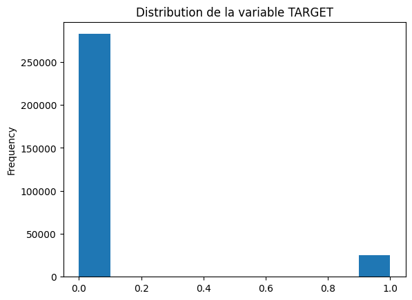

```python
fig = plt.figure()
data['TARGET'].plot.hist()
plt.title('Distribution de la variable TARGET')
plt.show()
```

**Problème de classe déséquilibré.**

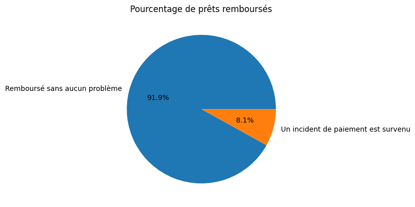

```python
fig = plt.figure()
plt.pie(data['TARGET'].value_counts()/len(data)*100,
        autopct='%1.1f%%',
        labels=["Remboursé sans aucun problème", "Un incident de paiement est survenu"]
       )
plt.title('Pourcentage de prêts remboursés')
plt.show()
```

- À partir de ces informations, nous voyons qu'il s'agit d'un problème de classe déséquilibré.
  - Il y a beaucoup plus de prêts qui ont été remboursés à temps que de prêts qui n'ont pas été remboursés.
- Dans des modèles d'apprentissage automatique plus sophistiqués, nous pourrons pondérer les classes en fonction de leur représentation dans les données pour refléter ce déséquilibre.
- **Une methode tel que SMOTE, Class Weight, undersampling devra être utilisée afin de pas biaiser les résultats de l'algorithme de scoring.**

## Analyse des valeurs manquantes

```
Valeurs manquantes :9152465 NaN pour        37516342 données (24.4 %)
-------------------------------------------------------------
Nombre et pourcentage de valeurs manquantes par variable
```

|  | Nombres de valeurs manquantes | % de valeurs manquantes |
| --- | --- | --- |
| COMMONAREA_MEDI | 214865 | 69.870000 |
| COMMONAREA_AVG | 214865 | 69.870000 |
| COMMONAREA_MODE | 214865 | 69.870000 |
| NONLIVINGAPARTMENTS_MEDI | 213514 | 69.430000 |
| NONLIVINGAPARTMENTS_MODE | 213514 | 69.430000 |
| NONLIVINGAPARTMENTS_AVG | 213514 | 69.430000 |
| FONDKAPREMONT_MODE | 210295 | 68.390000 |
| LIVINGAPARTMENTS_MODE | 210199 | 68.350000 |
| LIVINGAPARTMENTS_MEDI | 210199 | 68.350000 |
| LIVINGAPARTMENTS_AVG | 210199 | 68.350000 |
| FLOORSMIN_MODE | 208642 | 67.850000 |
| FLOORSMIN_MEDI | 208642 | 67.850000 |
| FLOORSMIN_AVG | 208642 | 67.850000 |
| YEARS_BUILD_MODE | 204488 | 66.500000 |
| YEARS_BUILD_MEDI | 204488 | 66.500000 |
| YEARS_BUILD_AVG | 204488 | 66.500000 |
| OWN_CAR_AGE | 202929 | 65.990000 |
| LANDAREA_AVG | 182590 | 59.380000 |
| LANDAREA_MEDI | 182590 | 59.380000 |
| LANDAREA_MODE | 182590 | 59.380000 |
| BASEMENTAREA_MEDI | 179943 | 58.520000 |
| BASEMENTAREA_AVG | 179943 | 58.520000 |
| BASEMENTAREA_MODE | 179943 | 58.520000 |
| EXT_SOURCE_1 | 173378 | 56.380000 |
| NONLIVINGAREA_MEDI | 169682 | 55.180000 |
| NONLIVINGAREA_MODE | 169682 | 55.180000 |
| NONLIVINGAREA_AVG | 169682 | 55.180000 |
| ELEVATORS_MEDI | 163891 | 53.300000 |
| ELEVATORS_MODE | 163891 | 53.300000 |
| ELEVATORS_AVG | 163891 | 53.300000 |
| WALLSMATERIAL_MODE | 156341 | 50.840000 |
| APARTMENTS_MODE | 156061 | 50.750000 |
| APARTMENTS_MEDI | 156061 | 50.750000 |
| APARTMENTS_AVG | 156061 | 50.750000 |
| ENTRANCES_MODE | 154828 | 50.350000 |
| ENTRANCES_AVG | 154828 | 50.350000 |
| ENTRANCES_MEDI | 154828 | 50.350000 |
| LIVINGAREA_MEDI | 154350 | 50.190000 |
| LIVINGAREA_MODE | 154350 | 50.190000 |
| LIVINGAREA_AVG | 154350 | 50.190000 |
| HOUSETYPE_MODE | 154297 | 50.180000 |
| FLOORSMAX_MEDI | 153020 | 49.760000 |
| FLOORSMAX_AVG | 153020 | 49.760000 |
| FLOORSMAX_MODE | 153020 | 49.760000 |
| YEARS_BEGINEXPLUATATION_AVG | 150007 | 48.780000 |
| YEARS_BEGINEXPLUATATION_MEDI | 150007 | 48.780000 |
| YEARS_BEGINEXPLUATATION_MODE | 150007 | 48.780000 |
| TOTALAREA_MODE | 148431 | 48.270000 |
| EMERGENCYSTATE_MODE | 145755 | 47.400000 |
| OCCUPATION_TYPE | 96391 | 31.350000 |
| EXT_SOURCE_3 | 60965 | 19.830000 |
| AMT_REQ_CREDIT_BUREAU_WEEK | 41519 | 13.500000 |
| AMT_REQ_CREDIT_BUREAU_DAY | 41519 | 13.500000 |
| AMT_REQ_CREDIT_BUREAU_MON | 41519 | 13.500000 |
| AMT_REQ_CREDIT_BUREAU_QRT | 41519 | 13.500000 |
| AMT_REQ_CREDIT_BUREAU_HOUR | 41519 | 13.500000 |
| AMT_REQ_CREDIT_BUREAU_YEAR | 41519 | 13.500000 |
| NAME_TYPE_SUITE | 1292 | 0.420000 |
| DEF_30_CNT_SOCIAL_CIRCLE | 1021 | 0.330000 |
| OBS_60_CNT_SOCIAL_CIRCLE | 1021 | 0.330000 |
| DEF_60_CNT_SOCIAL_CIRCLE | 1021 | 0.330000 |
| OBS_30_CNT_SOCIAL_CIRCLE | 1021 | 0.330000 |
| EXT_SOURCE_2 | 660 | 0.210000 |
| AMT_GOODS_PRICE | 278 | 0.090000 |
| DAYS_LAST_PHONE_CHANGE | 1 | 0.000000 |
| CNT_FAM_MEMBERS | 2 | 0.000000 |
| AMT_ANNUITY | 12 | 0.000000 |

```
-------------------------------------------------------------
Heatmap de visualisation des valeurs manquantes
```

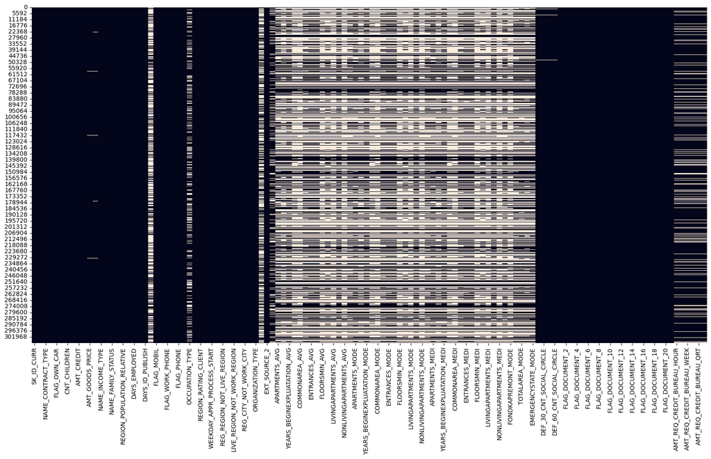

```python
get_missing_values(data, True, True)
```

- Lorsque viendra le temps de construire nos modèles d'apprentissage automatique, nous devrons remplir ces valeurs manquantes (appelées imputation).
- Dans des travaux ultérieurs, nous utiliserons des modèles tels que XGBoost qui peuvent gérer les valeurs manquantes sans nécessiter d'imputation.
- Une autre option serait de supprimer les colonnes avec un pourcentage élevé de valeurs manquantes, bien qu'il soit impossible de savoir à l'avance si ces colonnes seront utiles à notre modèle.
- **Par conséquent, nous conserverons toutes les colonnes pour le moment.**

### Les types de données

```python
# Number of each type of column
data.dtypes.value_counts()
```

```
float64    65
int64      41
object     16
Name: count, dtype: int64
```

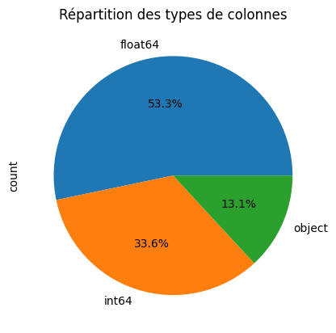

```python
data.dtypes.value_counts().plot(kind='pie',autopct="%1.1f%%", title = "Répartition des types de colonnes")
```

### Les entrées uniques des variables catégorielles

```python
# On visualise le nombre de valeurs uniques
for col in data.select_dtypes('object'):
    print(f'{col:-<50} {data[col].nunique()}')
    print(f'{col:-<50} {data[col].unique()}')
    print('-'*100)
```

```
NAME_CONTRACT_TYPE-------------------------------- 2
NAME_CONTRACT_TYPE-------------------------------- ['Cash loans' 'Revolving loans']
----------------------------------------------------------------------------------------------------
CODE_GENDER--------------------------------------- 3
CODE_GENDER--------------------------------------- ['M' 'F' 'XNA']
----------------------------------------------------------------------------------------------------
FLAG_OWN_CAR-------------------------------------- 2
FLAG_OWN_CAR-------------------------------------- ['N' 'Y']
----------------------------------------------------------------------------------------------------
FLAG_OWN_REALTY----------------------------------- 2
FLAG_OWN_REALTY----------------------------------- ['Y' 'N']
----------------------------------------------------------------------------------------------------
NAME_TYPE_SUITE----------------------------------- 7
NAME_TYPE_SUITE----------------------------------- ['Unaccompanied' 'Family' 'Spouse, partner' 'Children' 'Other_A' nan
 'Other_B' 'Group of people']
----------------------------------------------------------------------------------------------------
NAME_INCOME_TYPE---------------------------------- 8
NAME_INCOME_TYPE---------------------------------- ['Working' 'State servant' 'Commercial associate' 'Pensioner' 'Unemployed'
 'Student' 'Businessman' 'Maternity leave']
----------------------------------------------------------------------------------------------------
NAME_EDUCATION_TYPE------------------------------- 5
NAME_EDUCATION_TYPE------------------------------- ['Secondary / secondary special' 'Higher education' 'Incomplete higher'
 'Lower secondary' 'Academic degree']
----------------------------------------------------------------------------------------------------
NAME_FAMILY_STATUS-------------------------------- 6
NAME_FAMILY_STATUS-------------------------------- ['Single / not married' 'Married' 'Civil marriage' 'Widow' 'Separated'
 'Unknown']
----------------------------------------------------------------------------------------------------
NAME_HOUSING_TYPE--------------------------------- 6
NAME_HOUSING_TYPE--------------------------------- ['House / apartment' 'Rented apartment' 'With parents'
 'Municipal apartment' 'Office apartment' 'Co-op apartment']
----------------------------------------------------------------------------------------------------
OCCUPATION_TYPE----------------------------------- 18
OCCUPATION_TYPE----------------------------------- ['Laborers' 'Core staff' 'Accountants' 'Managers' nan 'Drivers'
 'Sales staff' 'Cleaning staff' 'Cooking staff' 'Private service staff'
 'Medicine staff' 'Security staff' 'High skill tech staff'
 'Waiters/barmen staff' 'Low-skill Laborers' 'Realty agents' 'Secretaries'
 'IT staff' 'HR staff']
----------------------------------------------------------------------------------------------------
WEEKDAY_APPR_PROCESS_START------------------------ 7
```

[output cut: 15 more lines]

```
 'Trade: type 4' 'Telecom' 'Industry: type 8' 'Realtor' 'Industry: type 6']
----------------------------------------------------------------------------------------------------
FONDKAPREMONT_MODE-------------------------------- 4
FONDKAPREMONT_MODE-------------------------------- ['reg oper account' nan 'org spec account' 'reg oper spec account'
 'not specified']
----------------------------------------------------------------------------------------------------
HOUSETYPE_MODE------------------------------------ 3
HOUSETYPE_MODE------------------------------------ ['block of flats' nan 'terraced house' 'specific housing']
----------------------------------------------------------------------------------------------------
WALLSMATERIAL_MODE-------------------------------- 7
WALLSMATERIAL_MODE-------------------------------- ['Stone, brick' 'Block' nan 'Panel' 'Mixed' 'Wooden' 'Others' 'Monolithic']
----------------------------------------------------------------------------------------------------
EMERGENCYSTATE_MODE------------------------------- 2
EMERGENCYSTATE_MODE------------------------------- ['No' nan 'Yes']
----------------------------------------------------------------------------------------------------
```

## Nettoyage

**NAME_CONTRACT_TYPE**

```python
# NAME_CONTRACT_TYPE
data.NAME_CONTRACT_TYPE.value_counts()
```

```
NAME_CONTRACT_TYPE
Cash loans         278232
Revolving loans     29279
Name: count, dtype: int64
```

**CODE_GENDER**

```python
data.CODE_GENDER.value_counts()
```

```
CODE_GENDER
F      202448
M      105059
XNA         4
Name: count, dtype: int64
```

```python
# Suppression des 4 lignes contenant un genre == XNA
data = data[data.CODE_GENDER != 'XNA']
data.CODE_GENDER.value_counts()
```

```
CODE_GENDER
F    202448
M    105059
Name: count, dtype: int64
```

**NAME_INCOME_TYPE**

```python
data['NAME_INCOME_TYPE'].value_counts()
```

```
NAME_INCOME_TYPE
Working                 158771
Commercial associate     71616
Pensioner                55362
State servant            21703
Unemployed                  22
Student                     18
Businessman                 10
Maternity leave              5
Name: count, dtype: int64
```

```python
data[data['NAME_INCOME_TYPE']=='Maternity leave']
```

|  | SK_ID_CURR | TARGET | NAME_CONTRACT_TYPE | CODE_GENDER | FLAG_OWN_CAR | FLAG_OWN_REALTY | CNT_CHILDREN | AMT_INCOME_TOTAL | AMT_CREDIT | AMT_ANNUITY | AMT_GOODS_PRICE | NAME_TYPE_SUITE | NAME_INCOME_TYPE | NAME_EDUCATION_TYPE | NAME_FAMILY_STATUS | NAME_HOUSING_TYPE | REGION_POPULATION_RELATIVE | DAYS_BIRTH | DAYS_EMPLOYED | DAYS_REGISTRATION | DAYS_ID_PUBLISH | OWN_CAR_AGE | FLAG_MOBIL | FLAG_EMP_PHONE | FLAG_WORK_PHONE | FLAG_CONT_MOBILE | FLAG_PHONE | FLAG_EMAIL | OCCUPATION_TYPE | … |
| --- | --- | --- | --- | --- | --- | --- | --- | --- | --- | --- | --- | --- | --- | --- | --- | --- | --- | --- | --- | --- | --- | --- | --- | --- | --- | --- | --- | --- | --- | --- |
| 48949 | 156685 | 0 | Revolving loans | M | N | N | 0 | 360000.0 | 765000.0 | 76500.0 | 765000.0 | Unaccompanied | Maternity leave | Higher education | Married | House / apartment | 0.0462 | -22166 | -3762 | -9228.0 | -4363 | NaN | 1 | 1 | 0 | 1 | 1 | 0 | NaN | … |
| 109612 | 227123 | 0 | Revolving loans | F | N | Y | 2 | 135000.0 | 810000.0 | 40500.0 | 810000.0 | Spouse, partner | Maternity leave | Higher education | Married | House / apartment | 0.0308 | -14943 | -1223 | -8853.0 | -3868 | NaN | 1 | 1 | 0 | 1 | 0 | 0 | Core staff | … |
| 218269 | 352877 | 1 | Cash loans | F | N | Y | 2 | 67500.0 | 1435500.0 | 40896.0 | 1435500.0 | Unaccompanied | Maternity leave | Secondary / secondary special | Married | House / apartment | 0.0069 | -13121 | -3629 | -795.0 | -1007 | NaN | 1 | 1 | 0 | 1 | 0 | 0 | Laborers | … |
| 291432 | 437628 | 1 | Cash loans | F | Y | Y | 2 | 49500.0 | 423000.0 | 11286.0 | 423000.0 | Spouse, partner | Maternity leave | Secondary / secondary special | Married | House / apartment | 0.0313 | -14363 | -3020 | -419.0 | -4333 | 8.0 | 1 | 1 | 0 | 1 | 0 | 0 | Core staff | … |
| 295458 | 442305 | 0 | Revolving loans | F | N | Y | 1 | 90000.0 | 315000.0 | 15750.0 | 315000.0 | Unaccompanied | Maternity leave | Higher education | Married | House / apartment | 0.0013 | -9519 | -1550 | -4266.0 | -768 | NaN | 1 | 1 | 0 | 1 | 1 | 0 | Accountants | … |

```python
cols_to_clean = data.select_dtypes('object').columns
```

```python
for cols in cols_to_clean:
    data[cols] = data[cols].apply(lambda x : cleaning_categories(x))
data[cols_to_clean]
```

|  | NAME_CONTRACT_TYPE | CODE_GENDER | FLAG_OWN_CAR | FLAG_OWN_REALTY | NAME_TYPE_SUITE | NAME_INCOME_TYPE | NAME_EDUCATION_TYPE | NAME_FAMILY_STATUS | NAME_HOUSING_TYPE | OCCUPATION_TYPE | WEEKDAY_APPR_PROCESS_START | ORGANIZATION_TYPE | FONDKAPREMONT_MODE | HOUSETYPE_MODE | WALLSMATERIAL_MODE | EMERGENCYSTATE_MODE |
| --- | --- | --- | --- | --- | --- | --- | --- | --- | --- | --- | --- | --- | --- | --- | --- | --- |
| 0 | CASH LOANS | M | N | Y | UNACCOMPANIED | WORKING | SECONDARY SECONDARY SPECIAL | SINGLE NOT MARRIED | HOUSE APARTMENT | LABORERS | WEDNESDAY | BUSINESS ENTITY TYPE 3 | REG OPER ACCOUNT | BLOCK OF FLATS | STONE, BRICK | NO |
| 1 | CASH LOANS | F | N | N | FAMILY | STATE SERVANT | HIGHER EDUCATION | MARRIED | HOUSE APARTMENT | CORE STAFF | MONDAY | SCHOOL | REG OPER ACCOUNT | BLOCK OF FLATS | BLOCK | NO |
| 2 | REVOLVING LOANS | M | Y | Y | UNACCOMPANIED | WORKING | SECONDARY SECONDARY SPECIAL | SINGLE NOT MARRIED | HOUSE APARTMENT | LABORERS | MONDAY | GOVERNMENT | NAN | NAN | NAN | NAN |
| 3 | CASH LOANS | F | N | Y | UNACCOMPANIED | WORKING | SECONDARY SECONDARY SPECIAL | CIVIL MARRIAGE | HOUSE APARTMENT | LABORERS | WEDNESDAY | BUSINESS ENTITY TYPE 3 | NAN | NAN | NAN | NAN |
| 4 | CASH LOANS | M | N | Y | UNACCOMPANIED | WORKING | SECONDARY SECONDARY SPECIAL | SINGLE NOT MARRIED | HOUSE APARTMENT | CORE STAFF | THURSDAY | RELIGION | NAN | NAN | NAN | NAN |
| ... | ... | ... | ... | ... | ... | ... | ... | ... | ... | ... | ... | ... | ... | ... | ... | ... |
| 307506 | CASH LOANS | M | N | N | UNACCOMPANIED | WORKING | SECONDARY SECONDARY SPECIAL | SEPARATED | WITH PARENTS | SALES STAFF | THURSDAY | SERVICES | REG OPER ACCOUNT | BLOCK OF FLATS | STONE, BRICK | NO |
| 307507 | CASH LOANS | F | N | Y | UNACCOMPANIED | PENSIONER | SECONDARY SECONDARY SPECIAL | WIDOW | HOUSE APARTMENT | NAN | MONDAY | XNA | REG OPER ACCOUNT | BLOCK OF FLATS | STONE, BRICK | NO |
| 307508 | CASH LOANS | F | N | Y | UNACCOMPANIED | WORKING | HIGHER EDUCATION | SEPARATED | HOUSE APARTMENT | MANAGERS | THURSDAY | SCHOOL | REG OPER ACCOUNT | BLOCK OF FLATS | PANEL | NO |
| 307509 | CASH LOANS | F | N | Y | UNACCOMPANIED | COMMERCIAL ASSOCIATE | SECONDARY SECONDARY SPECIAL | MARRIED | HOUSE APARTMENT | LABORERS | WEDNESDAY | BUSINESS ENTITY TYPE 1 | NAN | BLOCK OF FLATS | STONE, BRICK | NO |
| 307510 | CASH LOANS | F | N | N | UNACCOMPANIED | COMMERCIAL ASSOCIATE | HIGHER EDUCATION | MARRIED | HOUSE APARTMENT | LABORERS | THURSDAY | BUSINESS ENTITY TYPE 3 | NAN | BLOCK OF FLATS | PANEL | NO |

307507 rows × 16 columns

```python
for col in data.select_dtypes('object'):
    print(f'{col:-<50} {data[col].nunique()}')
    print(f'{col:-<50} {data[col].unique()}')
    print('-'*100)
```

```
NAME_CONTRACT_TYPE-------------------------------- 2
NAME_CONTRACT_TYPE-------------------------------- ['CASH LOANS' 'REVOLVING LOANS']
----------------------------------------------------------------------------------------------------
CODE_GENDER--------------------------------------- 2
CODE_GENDER--------------------------------------- ['M' 'F']
----------------------------------------------------------------------------------------------------
FLAG_OWN_CAR-------------------------------------- 2
FLAG_OWN_CAR-------------------------------------- ['N' 'Y']
----------------------------------------------------------------------------------------------------
FLAG_OWN_REALTY----------------------------------- 2
FLAG_OWN_REALTY----------------------------------- ['Y' 'N']
----------------------------------------------------------------------------------------------------
NAME_TYPE_SUITE----------------------------------- 8
NAME_TYPE_SUITE----------------------------------- ['UNACCOMPANIED' 'FAMILY' 'SPOUSE, PARTNER' 'CHILDREN' 'OTHER_A' 'NAN'
 'OTHER_B' 'GROUP OF PEOPLE']
----------------------------------------------------------------------------------------------------
NAME_INCOME_TYPE---------------------------------- 8
NAME_INCOME_TYPE---------------------------------- ['WORKING' 'STATE SERVANT' 'COMMERCIAL ASSOCIATE' 'PENSIONER' 'UNEMPLOYED'
 'STUDENT' 'BUSINESSMAN' 'MATERNITY LEAVE']
----------------------------------------------------------------------------------------------------
NAME_EDUCATION_TYPE------------------------------- 5
NAME_EDUCATION_TYPE------------------------------- ['SECONDARY   SECONDARY SPECIAL' 'HIGHER EDUCATION' 'INCOMPLETE HIGHER'
 'LOWER SECONDARY' 'ACADEMIC DEGREE']
----------------------------------------------------------------------------------------------------
NAME_FAMILY_STATUS-------------------------------- 6
NAME_FAMILY_STATUS-------------------------------- ['SINGLE   NOT MARRIED' 'MARRIED' 'CIVIL MARRIAGE' 'WIDOW' 'SEPARATED'
 'UNKNOWN']
----------------------------------------------------------------------------------------------------
NAME_HOUSING_TYPE--------------------------------- 6
NAME_HOUSING_TYPE--------------------------------- ['HOUSE   APARTMENT' 'RENTED APARTMENT' 'WITH PARENTS'
 'MUNICIPAL APARTMENT' 'OFFICE APARTMENT' 'COOP APARTMENT']
----------------------------------------------------------------------------------------------------
OCCUPATION_TYPE----------------------------------- 19
OCCUPATION_TYPE----------------------------------- ['LABORERS' 'CORE STAFF' 'ACCOUNTANTS' 'MANAGERS' 'NAN' 'DRIVERS'
 'SALES STAFF' 'CLEANING STAFF' 'COOKING STAFF' 'PRIVATE SERVICE STAFF'
 'MEDICINE STAFF' 'SECURITY STAFF' 'HIGH SKILL TECH STAFF'
 'WAITERS BARMEN STAFF' 'LOWSKILL LABORERS' 'REALTY AGENTS' 'SECRETARIES'
 'IT STAFF' 'HR STAFF']
----------------------------------------------------------------------------------------------------
WEEKDAY_APPR_PROCESS_START------------------------ 7
```

[output cut: 16 more lines]

```
----------------------------------------------------------------------------------------------------
FONDKAPREMONT_MODE-------------------------------- 5
FONDKAPREMONT_MODE-------------------------------- ['REG OPER ACCOUNT' 'NAN' 'ORG SPEC ACCOUNT' 'REG OPER SPEC ACCOUNT'
 'NOT SPECIFIED']
----------------------------------------------------------------------------------------------------
HOUSETYPE_MODE------------------------------------ 4
HOUSETYPE_MODE------------------------------------ ['BLOCK OF FLATS' 'NAN' 'TERRACED HOUSE' 'SPECIFIC HOUSING']
----------------------------------------------------------------------------------------------------
WALLSMATERIAL_MODE-------------------------------- 8
WALLSMATERIAL_MODE-------------------------------- ['STONE, BRICK' 'BLOCK' 'NAN' 'PANEL' 'MIXED' 'WOODEN' 'OTHERS'
 'MONOLITHIC']
----------------------------------------------------------------------------------------------------
EMERGENCYSTATE_MODE------------------------------- 3
EMERGENCYSTATE_MODE------------------------------- ['NO' 'NAN' 'YES']
----------------------------------------------------------------------------------------------------
```

La plupart des variables catégorielles ont un nombre relativement faible d'entrées uniques. Nous devrons trouver un moyen de traiter ces variables catégorielles :

- Label encoder
- OneHot encoder

```python
get_missing_values( data[cols_to_clean],False, False)
```

```
Valeurs manquantes :0 NaN pour        4920112 données (0.0 %)
```

## Encodage des variables catégorielles

Le problème avec l'encodage des étiquettes est qu'il donne aux catégories un ordre arbitraire. La valeur attribuée à chacune des catégories est aléatoire et ne reflète aucun aspect inhérent à la catégorie.

Lorsque nous effectuons un encodage d'étiquettes, le modèle peut utiliser la valeur relative de la fonctionnalité pour attribuer des poids qui ne sont pas ce que nous voulons. Si nous n'avons que deux valeurs uniques pour une variable catégorielle (telle que Homme/Femme), l'encodage des étiquettes est correct, mais pour plus de 2 catégories uniques, one-hot encoder est l'option sûre.

Le seul inconvénient de one-hot encoder est que le nombre de caractéristiques (dimensions des données) peut exploser avec des variables catégorielles avec de nombreuses catégories. Pour faire face à cela, nous pouvons effectuer un one-hot suivi de PCA ou d'autres méthodes de réduction de dimensionnalité pour réduire le nombre de dimensions (tout en essayant de préserver les informations).

**Dans ce notebook, nous utiliserons Label Encoding pour toutes les variables catégorielles avec seulement 2 catégories et One-Hot Encoding pour toutes les variables catégorielles avec plus de 2 catégories.**

```python
# Create a label encoder object
le = LabelEncoder()
le_count = 0

# Iterate through the columns
for col in data:
    if data[col].dtype == 'object':
        # If 2 or fewer unique categories
        if len(list(data[col].unique())) <= 2:
            # Train on the training data
            le.fit(data[col])
            # Transform both training and testing data
            data[col] = le.transform(data[col])

            # Keep track of how many columns were label encoded
            le_count += 1

print('%d columns were label encoded.' % le_count)
```

```
4 columns were label encoded.
```

```python
# one-hot encoding of categorical variables
data = pd.get_dummies(data)

print('Training Features shape: ', data.shape)
```

```
Training Features shape:  (307507, 247)
```

## Description des variables

```python
# Description des variables boolean
description_variables(data, type_var='bool')
```

|  | NAME_TYPE_SUITE_CHILDREN | NAME_TYPE_SUITE_FAMILY | NAME_TYPE_SUITE_GROUP OF PEOPLE | NAME_TYPE_SUITE_NAN | NAME_TYPE_SUITE_OTHER_A | NAME_TYPE_SUITE_OTHER_B | NAME_TYPE_SUITE_SPOUSE, PARTNER | NAME_TYPE_SUITE_UNACCOMPANIED | NAME_INCOME_TYPE_BUSINESSMAN | NAME_INCOME_TYPE_COMMERCIAL ASSOCIATE | NAME_INCOME_TYPE_MATERNITY LEAVE | NAME_INCOME_TYPE_PENSIONER | NAME_INCOME_TYPE_STATE SERVANT | NAME_INCOME_TYPE_STUDENT | NAME_INCOME_TYPE_UNEMPLOYED | NAME_INCOME_TYPE_WORKING | NAME_EDUCATION_TYPE_ACADEMIC DEGREE | NAME_EDUCATION_TYPE_HIGHER EDUCATION | NAME_EDUCATION_TYPE_INCOMPLETE HIGHER | NAME_EDUCATION_TYPE_LOWER SECONDARY | NAME_EDUCATION_TYPE_SECONDARY SECONDARY SPECIAL | NAME_FAMILY_STATUS_CIVIL MARRIAGE | NAME_FAMILY_STATUS_MARRIED | NAME_FAMILY_STATUS_SEPARATED | NAME_FAMILY_STATUS_SINGLE NOT MARRIED | NAME_FAMILY_STATUS_UNKNOWN | NAME_FAMILY_STATUS_WIDOW | NAME_HOUSING_TYPE_COOP APARTMENT | NAME_HOUSING_TYPE_HOUSE APARTMENT | … |
| --- | --- | --- | --- | --- | --- | --- | --- | --- | --- | --- | --- | --- | --- | --- | --- | --- | --- | --- | --- | --- | --- | --- | --- | --- | --- | --- | --- | --- | --- | --- |
| type | bool | bool | bool | bool | bool | bool | bool | bool | bool | bool | bool | bool | bool | bool | bool | bool | bool | bool | bool | bool | bool | bool | bool | bool | bool | bool | bool | bool | bool | … |
| nb_nan | 0.0 | 0.0 | 0.0 | 0.0 | 0.0 | 0.0 | 0.0 | 0.0 | 0.0 | 0.0 | 0.0 | 0.0 | 0.0 | 0.0 | 0.0 | 0.0 | 0.0 | 0.0 | 0.0 | 0.0 | 0.0 | 0.0 | 0.0 | 0.0 | 0.0 | 0.0 | 0.0 | 0.0 | 0.0 | … |
| %_nan | 0.0 | 0.0 | 0.0 | 0.0 | 0.0 | 0.0 | 0.0 | 0.0 | 0.0 | 0.0 | 0.0 | 0.0 | 0.0 | 0.0 | 0.0 | 0.0 | 0.0 | 0.0 | 0.0 | 0.0 | 0.0 | 0.0 | 0.0 | 0.0 | 0.0 | 0.0 | 0.0 | 0.0 | 0.0 | … |
| count | 307507 | 307507 | 307507 | 307507 | 307507 | 307507 | 307507 | 307507 | 307507 | 307507 | 307507 | 307507 | 307507 | 307507 | 307507 | 307507 | 307507 | 307507 | 307507 | 307507 | 307507 | 307507 | 307507 | 307507 | 307507 | 307507 | 307507 | 307507 | 307507 | … |
| unique | 2 | 2 | 2 | 2 | 2 | 2 | 2 | 2 | 2 | 2 | 2 | 2 | 2 | 2 | 2 | 2 | 2 | 2 | 2 | 2 | 2 | 2 | 2 | 2 | 2 | 2 | 2 | 2 | 2 | … |
| top | False | False | False | False | False | False | False | True | False | False | False | False | False | False | False | True | False | False | False | False | True | False | True | False | False | False | False | False | True | … |
| freq | 304240 | 267359 | 307236 | 306215 | 306641 | 305737 | 296137 | 248523 | 307497 | 235891 | 307502 | 252145 | 285804 | 307489 | 307485 | 158771 | 307343 | 232645 | 297231 | 303691 | 218389 | 277733 | 196429 | 287737 | 262063 | 307505 | 291419 | 306385 | 272865 | … |

### Outliers / Anomalies

- Les outliers/anomalies peuvent être dues à des nombres mal saisis, à des erreurs dans l'équipement de mesure ou à des mesures valides mais extrêmes. Une façon de prendre en charge quantitativement les anomalies consiste à examiner les statistiques d'une colonne à l'aide de la méthode de description.
- Les nombres dans la colonne DAYS_BIRTH sont négatifs car ils sont enregistrés par rapport à la demande de prêt en cours. Pour voir ces statistiques en années, nous pouvons multiplier par -1 et diviser par le nombre de jours dans une année :

```python
# Description des variables numériques
description_variables(data, type_var='num').T
```

|  | type | nb_nan | %_nan | count | mean | std | min | 25% | 50% | 75% | max |
| --- | --- | --- | --- | --- | --- | --- | --- | --- | --- | --- | --- |
| SK_ID_CURR | int64 | 0.0 | 0.0 | 307507.0 | 278181.5273 | 102790.133 | 100002.0 | 189146.5 | 278203.0 | 367143.5 | 456255.0 |
| TARGET | int64 | 0.0 | 0.0 | 307507.0 | 0.0807 | 0.2724 | 0.0 | 0.0 | 0.0 | 0.0 | 1.0 |
| NAME_CONTRACT_TYPE | int32 | 0.0 | 0.0 | 307507.0 | 0.0952 | 0.2935 | 0.0 | 0.0 | 0.0 | 0.0 | 1.0 |
| CODE_GENDER | int32 | 0.0 | 0.0 | 307507.0 | 0.3416 | 0.4743 | 0.0 | 0.0 | 0.0 | 1.0 | 1.0 |
| FLAG_OWN_CAR | int32 | 0.0 | 0.0 | 307507.0 | 0.3401 | 0.4737 | 0.0 | 0.0 | 0.0 | 1.0 | 1.0 |
| FLAG_OWN_REALTY | int32 | 0.0 | 0.0 | 307507.0 | 0.6937 | 0.461 | 0.0 | 0.0 | 1.0 | 1.0 | 1.0 |
| CNT_CHILDREN | int64 | 0.0 | 0.0 | 307507.0 | 0.417 | 0.7221 | 0.0 | 0.0 | 0.0 | 1.0 | 19.0 |
| AMT_INCOME_TOTAL | float64 | 0.0 | 0.0 | 307507.0 | 168797.6858 | 237124.6273 | 25650.0 | 112500.0 | 147150.0 | 202500.0 | 117000000.0 |
| AMT_CREDIT | float64 | 0.0 | 0.0 | 307507.0 | 599028.5967 | 402492.6019 | 45000.0 | 270000.0 | 513531.0 | 808650.0 | 4050000.0 |
| AMT_ANNUITY | float64 | 12.0 | 0.0039 | 307495.0 | 27108.6668 | 14493.7984 | 1615.5 | 16524.0 | 24903.0 | 34596.0 | 258025.5 |
| AMT_GOODS_PRICE | float64 | 278.0 | 0.0904 | 307229.0 | 538397.7245 | 369447.2465 | 40500.0 | 238500.0 | 450000.0 | 679500.0 | 4050000.0 |
| REGION_POPULATION_RELATIVE | float64 | 0.0 | 0.0 | 307507.0 | 0.0209 | 0.0138 | 0.0003 | 0.01 | 0.0188 | 0.0287 | 0.0725 |
| DAYS_BIRTH | int64 | 0.0 | 0.0 | 307507.0 | -16037.0273 | 4363.9824 | -25229.0 | -19682.0 | -15750.0 | -12413.0 | -7489.0 |
| DAYS_EMPLOYED | int64 | 0.0 | 0.0 | 307507.0 | 63815.9292 | 141276.4725 | -17912.0 | -2760.0 | -1213.0 | -289.0 | 365243.0 |
| DAYS_REGISTRATION | float64 | 0.0 | 0.0 | 307507.0 | -4986.1314 | 3522.883 | -24672.0 | -7479.5 | -4504.0 | -2010.0 | 0.0 |
| DAYS_ID_PUBLISH | int64 | 0.0 | 0.0 | 307507.0 | -2994.2017 | 1509.4546 | -7197.0 | -4299.0 | -3254.0 | -1720.0 | 0.0 |
| OWN_CAR_AGE | float64 | 202927.0 | 65.991 | 104580.0 | 12.0611 | 11.9449 | 0.0 | 5.0 | 9.0 | 15.0 | 91.0 |
| FLAG_MOBIL | int64 | 0.0 | 0.0 | 307507.0 | 1.0 | 0.0018 | 0.0 | 1.0 | 1.0 | 1.0 | 1.0 |
| FLAG_EMP_PHONE | int64 | 0.0 | 0.0 | 307507.0 | 0.8199 | 0.3843 | 0.0 | 1.0 | 1.0 | 1.0 | 1.0 |
| FLAG_WORK_PHONE | int64 | 0.0 | 0.0 | 307507.0 | 0.1994 | 0.3995 | 0.0 | 0.0 | 0.0 | 0.0 | 1.0 |
| FLAG_CONT_MOBILE | int64 | 0.0 | 0.0 | 307507.0 | 0.9981 | 0.0432 | 0.0 | 1.0 | 1.0 | 1.0 | 1.0 |
| FLAG_PHONE | int64 | 0.0 | 0.0 | 307507.0 | 0.2811 | 0.4495 | 0.0 | 0.0 | 0.0 | 1.0 | 1.0 |
| FLAG_EMAIL | int64 | 0.0 | 0.0 | 307507.0 | 0.0567 | 0.2313 | 0.0 | 0.0 | 0.0 | 0.0 | 1.0 |
| CNT_FAM_MEMBERS | float64 | 2.0 | 0.0007 | 307505.0 | 2.1527 | 0.9107 | 1.0 | 2.0 | 2.0 | 3.0 | 20.0 |
| REGION_RATING_CLIENT | int64 | 0.0 | 0.0 | 307507.0 | 2.0525 | 0.509 | 1.0 | 2.0 | 2.0 | 2.0 | 3.0 |
| REGION_RATING_CLIENT_W_CITY | int64 | 0.0 | 0.0 | 307507.0 | 2.0315 | 0.5027 | 1.0 | 2.0 | 2.0 | 2.0 | 3.0 |
| HOUR_APPR_PROCESS_START | int64 | 0.0 | 0.0 | 307507.0 | 12.0634 | 3.2658 | 0.0 | 10.0 | 12.0 | 14.0 | 23.0 |
| REG_REGION_NOT_LIVE_REGION | int64 | 0.0 | 0.0 | 307507.0 | 0.0151 | 0.1221 | 0.0 | 0.0 | 0.0 | 0.0 | 1.0 |
| REG_REGION_NOT_WORK_REGION | int64 | 0.0 | 0.0 | 307507.0 | 0.0508 | 0.2195 | 0.0 | 0.0 | 0.0 | 0.0 | 1.0 |
| LIVE_REGION_NOT_WORK_REGION | int64 | 0.0 | 0.0 | 307507.0 | 0.0407 | 0.1975 | 0.0 | 0.0 | 0.0 | 0.0 | 1.0 |

[output cut: 80 more lines]

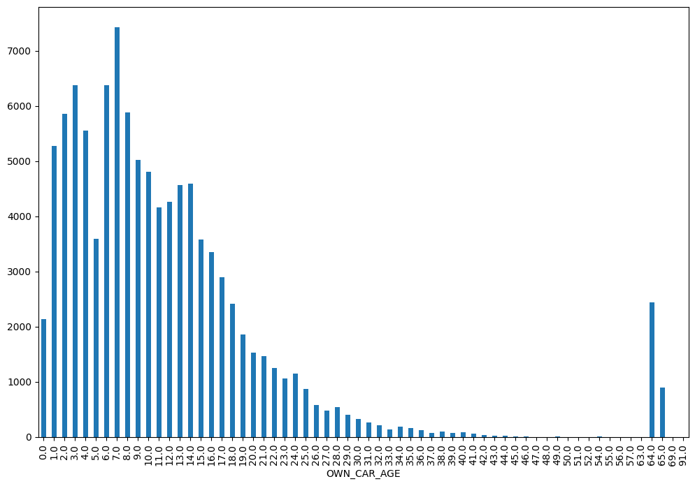

```python
plt.figure(figsize=(12,8))
data.OWN_CAR_AGE.value_counts().sort_index(ascending = True).plot(kind='bar')
plt.show()
```

```python
data.OWN_CAR_AGE.value_counts().sort_index(ascending = False).head(15)
```

```
OWN_CAR_AGE
91.0       2
69.0       1
65.0     891
64.0    2443
63.0       2
57.0       1
56.0       1
55.0       4
54.0      12
52.0       1
51.0       3
50.0       1
49.0       6
48.0       1
47.0       1
Name: count, dtype: int64
```

Plusieurs véhicules ont 64 ans, ou même sont plus vieux. Cela peut être des véhicules de collections ou tres bien entretenus.

91 ans est conservé comme valeurs exceptionnelle mais non impossible.

Ramenons-nous à des années pour étudier les variables DAYS_

**DAY_BIRTH**

```python
(data['DAYS_BIRTH'] / -365).describe()
```

```
count    307507.0000
mean         43.9371
std          11.9561
min          20.5178
25%          34.0082
50%          43.1507
75%          53.9233
max          69.1205
Name: DAYS_BIRTH, dtype: float64
```

Les âges semblent raisonnables. Il n'y a pas de valeurs aberrantes pour l'âge, que ce soit à l'extrémité supérieure ou inférieure.

L'âge maximal est 69 et le minimal es 20 ans, il n'y a pas d'outliers.

**DAYS_EMPLOYED**

```python
data['DAYS_EMPLOYED'].describe()
```

```
count    307507.0000
mean      63815.9292
std      141276.4725
min      -17912.0000
25%       -2760.0000
50%       -1213.0000
75%        -289.0000
max      365243.0000
Name: DAYS_EMPLOYED, dtype: float64
```

```python
print(f"Nombre maximal de jours où le client occupe son poste actuel précédents la demande :{(data['DAYS_EMPLOYED']/365).max()} ans")
```

```
Nombre maximal de jours où le client occupe son poste actuel précédents la demande :1000.6657534246575 ans
```

Cela ne semble pas correct : La valeur maximale (en plus d'être positive) est d'environ 1000 ans : 365243/365 = 1 000,6657

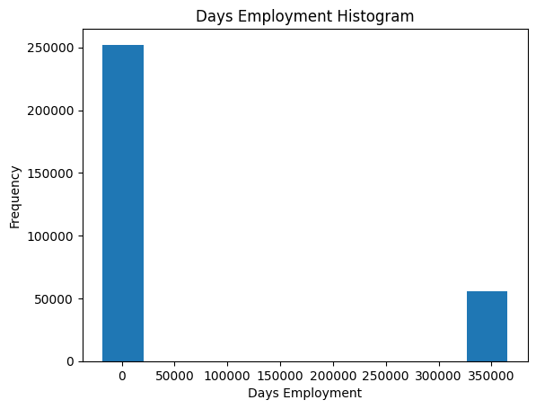

```python
data['DAYS_EMPLOYED'].plot.hist(title = 'Days Employment Histogram');
plt.xlabel('Days Employment')
```

```python
#identification des valeurs anormales et non anormales
anom = data[data['DAYS_EMPLOYED'] == data['DAYS_EMPLOYED'].max()]
non_anom = data[data['DAYS_EMPLOYED'] != data['DAYS_EMPLOYED'].max()]
print('La valeur par défaut des non-anomalies sur le %0.2f%% de prêts' % (100 * non_anom['TARGET'].mean()))
print('La valeur par défaut des anomalies sur le %0.2f%% de prêts' % (100 * anom['TARGET'].mean()))
print('Il y a %d outliers dans la variable days of employment' % len(anom))
```

```
La valeur par défaut des non-anomalies sur le 8.66% de prêts
La valeur par défaut des anomalies sur le 5.40% de prêts
Il y a 55374 outliers dans la variable days of employment
```

Il s'avère que les anomalies ont un taux de défaillance plus faible.  
Le traitement des anomalies dépend de la situation exacte, et il n'existe pas de règles fixes. L'une des approches les plus sûres consiste à définir les anomalies comme des valeurs manquantes, puis à les compléter (en utilisant l'imputation) avant l'apprentissage automatique.

Dans ce cas, **puisque toutes les anomalies ont exactement la même valeur**, nous pourrons les compléter avec la même valeur au cas où tous ces prêts ont quelque chose en commun.  
**Les valeurs anormales semblent avoir une certaine importance**, nous voulons donc indiquer au modèle d'apprentissage automatique si nous avons effectivement rempli ces valeurs.

Comme **solution**, nous allons remplir les valeurs anormales avec un nombre nul (np.nan) et ensuite créer une nouvelle colonne booléenne indiquant si la valeur était anormale ou non.

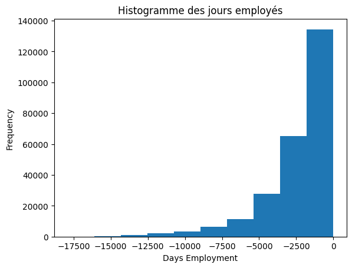

```python
#Création d'une colonne avec le label d'anomalie
data['DAYS_EMPLOYED_ANOM'] = data["DAYS_EMPLOYED"] == 365243

#On remplace les outliers par des nan
data['DAYS_EMPLOYED'].replace({365243: np.nan}, inplace = True)

data['DAYS_EMPLOYED'].plot.hist(title = 'Histogramme des jours employés');
plt.xlabel('Days Employment')
```

### Train et Test et Export

```python
# app_train, app_test = train_test_split(data, test_size=0.2)
# print("Données train : ",app_train.shape)
# print("Données test : ", app_test.shape)
```

```python
# Export en conservant les type
# app_train.to_csv('data/cleaned/train.csv', index=False)
# app_test.to_csv('data/cleaned/test.csv', index=False)
```

```python
train = pd.read_csv('data/cleaned/train.csv')
test = pd.read_csv('data/cleaned/test.csv')
print('Training data shape: ', train.shape)
print('Training data shape: ', test.shape)
```

```
Training data shape:  (246005, 248)
Training data shape:  (61502, 248)
```

## Corrélations

Maintenant que nous avons traité les variables catégorielles et les valeurs aberrantes, continuons avec l'EDA. Une façon d'essayer de comprendre les données consiste à rechercher des corrélations entre les caractéristiques et la cible. Nous pouvons calculer le coefficient de corrélation de Pearson entre chaque variable et la cible en utilisant la méthode de trame de données .corr.

Le coefficient de corrélation n'est pas la meilleure méthode pour représenter la 'pertinence' d'une caractéristique, mais il nous donne une idée des relations possibles au sein des données. Voici quelques interprétations générales de la valeur absolue du coefficient de corrélation :

- .00-.19 “très faible”
- .20-.39 “faible”
- .40-.59 “modéré”
- .60-.79 “fort”
- .80-1.0 “très fort”

```python
#Trouvons les corrélations avec la target et trions les
correlations = train.corr()['TARGET'].sort_values()
# Display correlations
print('Most Positive Correlations:\n', correlations.tail(15))
print('\nMost Negative Correlations:\n', correlations.head(15))
```

```
Most Positive Correlations:
 FLAG_DOCUMENT_3                                      0.0421
EMERGENCYSTATE_MODE_NAN                              0.0427
REG_CITY_NOT_LIVE_CITY                               0.0443
FLAG_EMP_PHONE                                       0.0455
NAME_EDUCATION_TYPE_SECONDARY   SECONDARY SPECIAL    0.0500
DAYS_ID_PUBLISH                                      0.0507
REG_CITY_NOT_WORK_CITY                               0.0514
CODE_GENDER                                          0.0530
DAYS_LAST_PHONE_CHANGE                               0.0556
NAME_INCOME_TYPE_WORKING                             0.0574
REGION_RATING_CLIENT                                 0.0596
REGION_RATING_CLIENT_W_CITY                          0.0618
DAYS_EMPLOYED                                        0.0756
DAYS_BIRTH                                           0.0777
TARGET                                               1.0000
Name: TARGET, dtype: float64

Most Negative Correlations:
 EXT_SOURCE_3                           -0.1785
EXT_SOURCE_2                           -0.1618
EXT_SOURCE_1                           -0.1522
NAME_EDUCATION_TYPE_HIGHER EDUCATION   -0.0564
NAME_INCOME_TYPE_PENSIONER             -0.0457
ORGANIZATION_TYPE_XNA                  -0.0455
DAYS_EMPLOYED_ANOM                     -0.0455
FLOORSMAX_AVG                          -0.0441
FLOORSMAX_MEDI                         -0.0438
EMERGENCYSTATE_MODE_NO                 -0.0435
FLOORSMAX_MODE                         -0.0434
HOUSETYPE_MODE_BLOCK OF FLATS          -0.0423
AMT_GOODS_PRICE                        -0.0405
REGION_POPULATION_RELATIVE             -0.0377
OCCUPATION_TYPE_NAN                    -0.0367
Name: TARGET, dtype: float64
```

Regardons certaines des corrélations les plus significatives :

- La corrélation **DAYS_BIRTH** est la plus positive.
- La corrélation est positive, mais la valeur de cette caractéristique est en fait négative, ce qui signifie que plus le client vieillit, moins il est susceptible de ne pas rembourser son prêt (c'est-à-dire que la cible == 0).
- C'est un peu déroutant, nous allons donc prendre la valeur absolue de la caractéristique et la corrélation sera alors négative.

**Effet de l'age sur la target**

```python
# Find the correlation of the positive days since birth and target
train['DAYS_BIRTH'] = abs(train['DAYS_BIRTH'])
print("Corrélation entre l'âge du client au moment du prêt et la TARGET :", train['DAYS_BIRTH'].corr(train['TARGET']))
```

```
Corrélation entre l'âge du client au moment du prêt et la TARGET : -0.0777327700400153
```

- Plus les clients vieillissent, plus ils ont tendance à rembourser leurs prêts dans les délais.

Examinons cette variable :

- Tout d'abord, nous pouvons faire un histogramme de l'âge.
- Nous allons mettre l'axe des x en années
- pour rendre le graphique un peu plus compréhensible.

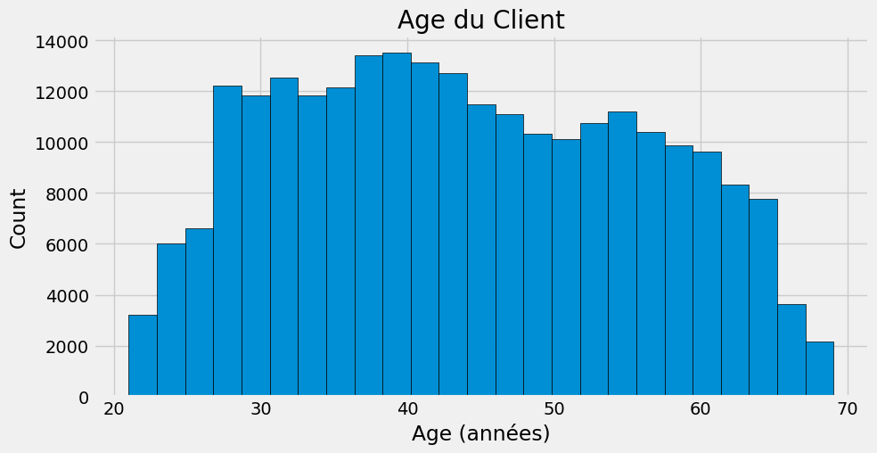

```python
# choix du style du tracé
plt.style.use('fivethirtyeight')

# Tracé de la distribution des ages
plt.figure(figsize=(10,5))
plt.hist(train['DAYS_BIRTH'] / 365, edgecolor = 'k', bins = 25)
plt.title('Age du Client'); plt.xlabel('Age (années)'); plt.ylabel('Count');
```

En soi, la distribution de l'âge ne nous dit pas grand-chose d'autre que le fait qu'il n'y a pas de valeurs aberrantes car tous les âges sont raisonnables. Pour visualiser l'effet de l'âge sur la cible, nous allons ensuite créer un graphique d'estimation de la densité du noyau (KDE) coloré par la valeur de la cible. Un diagramme d'estimation de la densité du noyau montre la distribution d'une seule variable et peut être considéré comme un histogramme lissé (il est créé en calculant un noyau, généralement un gaussien, à chaque point de données, puis en faisant la moyenne de tous les noyaux individuels pour développer un seul noyau lisse. courbe). Nous utiliserons le Seaborn kdeplot pour ce graphique.

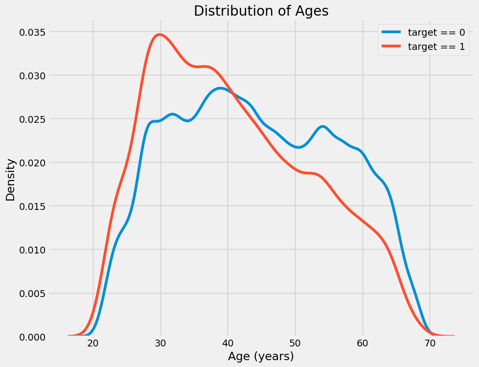

```python
plt.figure(figsize = (10, 8))

# KDE plot of loans that were repaid on time
sns.kdeplot(train.loc[train['TARGET'] == 0, 'DAYS_BIRTH'] / 365, label = 'target == 0')

# KDE plot of loans which were not repaid on time
sns.kdeplot(train.loc[train['TARGET'] == 1, 'DAYS_BIRTH'] / 365, label = 'target == 1')

# Labeling of plot
plt.xlabel('Age (years)'); plt.ylabel('Density'); plt.title('Distribution of Ages');
plt.legend()
```

La courbe cible == 1 s'incline vers l'extrémité la plus jeune de la plage. Bien qu'il ne s'agisse pas d'une corrélation significative (coefficient de corrélation de -0,07), cette variable sera probablement utile dans un modèle d'apprentissage automatique car elle affecte la cible. Regardons cette relation sous un autre angle : incapacité moyenne à rembourser les crédits par tranche d'âge.

Pour faire ce graphique, nous avons d'abord découpé la catégorie d'âge en tranches de 5 ans chacune. Ensuite, pour chaque bac, nous calculons la valeur moyenne de la cible, qui nous indique le ratio de prêts non remboursés dans chaque catégorie d'âge.

```python
# Age information into a separate dataframe
age_data = train[['TARGET', 'DAYS_BIRTH']]
age_data['YEARS_BIRTH'] = age_data['DAYS_BIRTH'] / 365

# Bin the age data
age_data['YEARS_BINNED'] = pd.cut(age_data['YEARS_BIRTH'], bins = np.linspace(20, 70, num = 11))
age_data.head(10)
```

|  | TARGET | DAYS_BIRTH | YEARS_BIRTH | YEARS_BINNED |
| --- | --- | --- | --- | --- |
| 0 | 0 | 19649 | 53.8329 | (50.0, 55.0] |
| 1 | 0 | 20660 | 56.6027 | (55.0, 60.0] |
| 2 | 0 | 14730 | 40.3562 | (40.0, 45.0] |
| 3 | 0 | 14964 | 40.9973 | (40.0, 45.0] |
| 4 | 0 | 15194 | 41.6274 | (40.0, 45.0] |
| 5 | 0 | 15251 | 41.7836 | (40.0, 45.0] |
| 6 | 0 | 13418 | 36.7616 | (35.0, 40.0] |
| 7 | 1 | 12221 | 33.4822 | (30.0, 35.0] |
| 8 | 0 | 15333 | 42.0082 | (40.0, 45.0] |
| 9 | 0 | 20800 | 56.9863 | (55.0, 60.0] |

```python
# Group by the bin and calculate averages
age_groups  = age_data.groupby('YEARS_BINNED').mean()
age_groups
```

| YEARS_BINNED | TARGET | DAYS_BIRTH | YEARS_BIRTH |
| --- | --- | --- | --- |
| (20.0, 25.0] | 0.1241 | 8531.9716 | 23.3753 |
| (25.0, 30.0] | 0.1111 | 10157.1447 | 27.8278 |
| (30.0, 35.0] | 0.1038 | 11855.0195 | 32.4795 |
| (35.0, 40.0] | 0.0889 | 13707.2566 | 37.5541 |
| (40.0, 45.0] | 0.0787 | 15495.8716 | 42.4544 |
| (45.0, 50.0] | 0.0739 | 17323.0270 | 47.4603 |
| (50.0, 55.0] | 0.0670 | 19197.7474 | 52.5966 |
| (55.0, 60.0] | 0.0559 | 20983.1253 | 57.4880 |
| (60.0, 65.0] | 0.0532 | 22780.5652 | 62.4125 |
| (65.0, 70.0] | 0.0386 | 24291.7268 | 66.5527 |

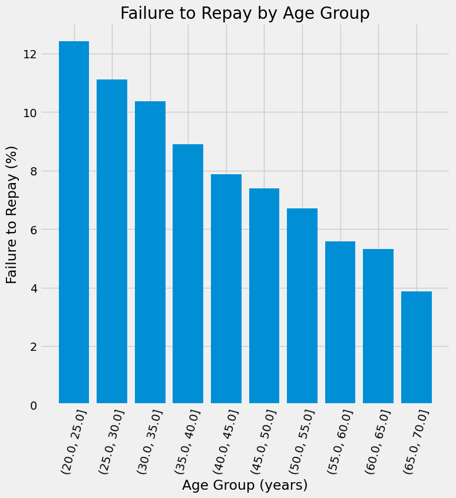

```python
plt.figure(figsize = (8, 8))

# Graph the age bins and the average of the target as a bar plot
plt.bar(age_groups.index.astype(str), 100 * age_groups['TARGET'])

# Plot labeling
plt.xticks(rotation = 75); plt.xlabel('Age Group (years)'); plt.ylabel('Failure to Repay (%)')
plt.title('Failure to Repay by Age Group')
```

Il y a une tendance claire : les jeunes demandeurs sont plus susceptibles de ne pas rembourser le prêt ! Le taux d'impayés est supérieur à 10 % pour les trois tranches d'âge les plus jeunes et inférieur à 5 % pour la tranche d'âge la plus élevée.

Il s'agit d'informations qui pourraient être directement utilisées par la banque : étant donné que les clients plus jeunes sont moins susceptibles de rembourser le prêt, il faudrait peut-être leur fournir davantage de conseils ou de conseils de planification financière. Cela ne signifie pas que la banque devrait discriminer les jeunes clients, mais il serait judicieux de prendre des mesures de précaution pour aider les jeunes clients à payer à temps.

```python
data_cor_selection_col = correlations.head(15).index.to_list()
data_cor_selection = train[data_cor_selection_col]
data_cor_selection['TARGET'] = train['TARGET']
data_cor_selection_corrs = data_cor_selection.corr()
data_cor_selection_corrs
```

|  | EXT_SOURCE_3 | EXT_SOURCE_2 | EXT_SOURCE_1 | NAME_EDUCATION_TYPE_HIGHER EDUCATION | NAME_INCOME_TYPE_PENSIONER | ORGANIZATION_TYPE_XNA | DAYS_EMPLOYED_ANOM | FLOORSMAX_AVG | FLOORSMAX_MEDI | EMERGENCYSTATE_MODE_NO | FLOORSMAX_MODE | HOUSETYPE_MODE_BLOCK OF FLATS | AMT_GOODS_PRICE | REGION_POPULATION_RELATIVE | OCCUPATION_TYPE_NAN | TARGET |
| --- | --- | --- | --- | --- | --- | --- | --- | --- | --- | --- | --- | --- | --- | --- | --- | --- |
| EXT_SOURCE_3 | 1.0000 | 0.1103 | 0.1881 | -0.0219 | 0.1151 | 0.1151 | 0.1151 | 0.0048 | 0.0050 | 0.0140 | 0.0051 | 0.0135 | 0.0476 | -0.0061 | 0.0761 | -0.1785 |
| EXT_SOURCE_2 | 0.1103 | 1.0000 | 0.2136 | 0.1246 | -0.0212 | -0.0212 | -0.0212 | 0.1332 | 0.1320 | 0.1276 | 0.1273 | 0.1246 | 0.1391 | 0.1989 | -0.0104 | -0.1618 |
| EXT_SOURCE_1 | 0.1881 | 0.2136 | 1.0000 | 0.1344 | 0.2948 | 0.2947 | 0.2947 | 0.0934 | 0.0925 | 0.0970 | 0.0898 | 0.0933 | 0.1768 | 0.1001 | 0.1873 | -0.1522 |
| NAME_EDUCATION_TYPE_HIGHER EDUCATION | -0.0219 | 0.1246 | 0.1344 | 1.0000 | -0.1056 | -0.1055 | -0.1055 | 0.1422 | 0.1417 | 0.1089 | 0.1388 | 0.1055 | 0.1402 | 0.0651 | -0.0463 | -0.0564 |
| NAME_INCOME_TYPE_PENSIONER | 0.1151 | -0.0212 | 0.2948 | -0.1056 | 1.0000 | 0.9997 | 0.9997 | -0.0173 | -0.0175 | -0.0124 | -0.0163 | -0.0112 | -0.0620 | -0.0036 | 0.6940 | -0.0457 |
| ORGANIZATION_TYPE_XNA | 0.1151 | -0.0212 | 0.2947 | -0.1055 | 0.9997 | 1.0000 | 1.0000 | -0.0173 | -0.0175 | -0.0124 | -0.0163 | -0.0113 | -0.0618 | -0.0036 | 0.6942 | -0.0455 |
| DAYS_EMPLOYED_ANOM | 0.1151 | -0.0212 | 0.2947 | -0.1055 | 0.9997 | 1.0000 | 1.0000 | -0.0173 | -0.0175 | -0.0124 | -0.0163 | -0.0113 | -0.0618 | -0.0036 | 0.6942 | -0.0455 |
| FLOORSMAX_AVG | 0.0048 | 0.1332 | 0.0934 | 0.1422 | -0.0173 | -0.0173 | -0.0173 | 1.0000 | 0.9970 | 0.1349 | 0.9859 | 0.0800 | 0.1097 | 0.3211 | 0.0097 | -0.0441 |
| FLOORSMAX_MEDI | 0.0050 | 0.1320 | 0.0925 | 0.1417 | -0.0175 | -0.0175 | -0.0175 | 0.9970 | 1.0000 | 0.1347 | 0.9885 | 0.0792 | 0.1092 | 0.3168 | 0.0093 | -0.0438 |
| EMERGENCYSTATE_MODE_NO | 0.0140 | 0.1276 | 0.0970 | 0.1089 | -0.0124 | -0.0124 | -0.0124 | 0.1349 | 0.1347 | 1.0000 | 0.1371 | 0.9159 | 0.0630 | 0.1028 | -0.0007 | -0.0435 |
| FLOORSMAX_MODE | 0.0051 | 0.1273 | 0.0898 | 0.1388 | -0.0163 | -0.0163 | -0.0163 | 0.9859 | 0.9885 | 0.1371 | 1.0000 | 0.0800 | 0.1065 | 0.3029 | 0.0096 | -0.0434 |
| HOUSETYPE_MODE_BLOCK OF FLATS | 0.0135 | 0.1246 | 0.0933 | 0.1055 | -0.0112 | -0.0113 | -0.0113 | 0.0800 | 0.0792 | 0.9159 | 0.0800 | 1.0000 | 0.0618 | 0.1066 | -0.0009 | -0.0423 |
| AMT_GOODS_PRICE | 0.0476 | 0.1391 | 0.1768 | 0.1402 | -0.0620 | -0.0618 | -0.0618 | 0.1097 | 0.1092 | 0.0630 | 0.1065 | 0.0618 | 1.0000 | 0.1033 | -0.0377 | -0.0405 |
| REGION_POPULATION_RELATIVE | -0.0061 | 0.1989 | 0.1001 | 0.0651 | -0.0036 | -0.0036 | -0.0036 | 0.3211 | 0.3168 | 0.1028 | 0.3029 | 0.1066 | 0.1033 | 1.0000 | 0.0172 | -0.0377 |
| OCCUPATION_TYPE_NAN | 0.0761 | -0.0104 | 0.1873 | -0.0463 | 0.6940 | 0.6942 | 0.6942 | 0.0097 | 0.0093 | -0.0007 | 0.0096 | -0.0009 | -0.0377 | 0.0172 | 1.0000 | -0.0367 |
| TARGET | -0.1785 | -0.1618 | -0.1522 | -0.0564 | -0.0457 | -0.0455 | -0.0455 | -0.0441 | -0.0438 | -0.0435 | -0.0434 | -0.0423 | -0.0405 | -0.0377 | -0.0367 | 1.0000 |

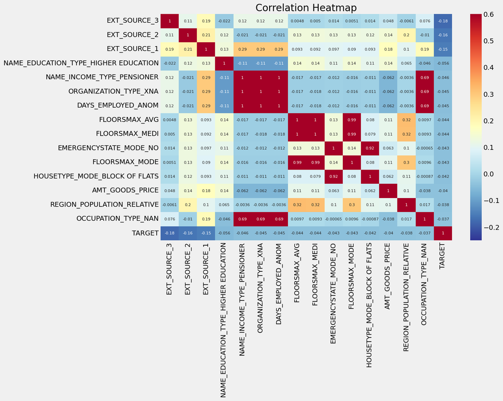

```python
plt.figure(figsize = (12, 8))

# Heatmap of correlations
sns.heatmap(data_cor_selection_corrs, cmap = plt.cm.RdYlBu_r, vmin = -0.25,
            annot = True,
            annot_kws={"size":8},
            vmax = 0.6)
plt.title('Correlation Heatmap')
```

## Sources extérieures

Les 3 variables avec les corrélations négatives les plus fortes avec la cible sont EXT_SOURCE_1, EXT_SOURCE_2 et EXT_SOURCE_3. Selon la documentation, ces fonctionnalités représentent un 'score normalisé à partir d'une source de données externe'. Je ne suis pas sûr de ce que cela signifie exactement, mais il peut s'agir d'une sorte de cote de crédit cumulative établie à l'aide de nombreuses sources de données.

Examinons ces variables. Les variables avec les plus fortes corrélations négatives sont les variables EXT nous pouvons montrer les corrélations des caractéristiques EXT_SOURCE avec la cible et entre elles.

```python
# Extract the EXT_SOURCE variables and show correlations
ext_data = train[['TARGET', 'EXT_SOURCE_1', 'EXT_SOURCE_2', 'EXT_SOURCE_3', 'DAYS_BIRTH']]
ext_data_corrs = ext_data.corr()
ext_data_corrs
```

|  | TARGET | EXT_SOURCE_1 | EXT_SOURCE_2 | EXT_SOURCE_3 | DAYS_BIRTH |
| --- | --- | --- | --- | --- | --- |
| TARGET | 1.0000 | -0.1522 | -0.1618 | -0.1785 | -0.0777 |
| EXT_SOURCE_1 | -0.1522 | 1.0000 | 0.2136 | 0.1881 | 0.6008 |
| EXT_SOURCE_2 | -0.1618 | 0.2136 | 1.0000 | 0.1103 | 0.0919 |
| EXT_SOURCE_3 | -0.1785 | 0.1881 | 0.1103 | 1.0000 | 0.2062 |
| DAYS_BIRTH | -0.0777 | 0.6008 | 0.0919 | 0.2062 | 1.0000 |

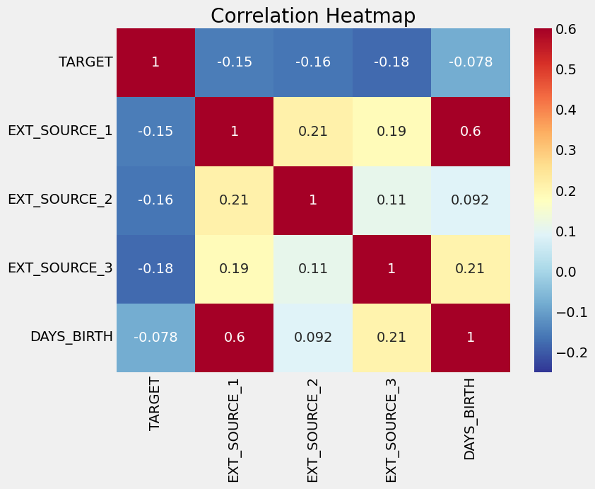

```python
plt.figure(figsize = (8, 6))

# Heatmap of correlations
sns.heatmap(ext_data_corrs, cmap = plt.cm.RdYlBu_r, vmin = -0.25, annot = True, vmax = 0.6)
plt.title('Correlation Heatmap')
```

Les trois caractéristiques EXT_SOURCE ont des corrélations négatives avec la cible, ce qui indique qu'à mesure que la valeur de EXT_SOURCE augmente, le client est plus susceptible de rembourser le prêt. Nous pouvons également voir que DAYS_BIRTH est positivement corrélé avec EXT_SOURCE_1 indiquant que l'un des facteurs de ce score est peut-être l'âge du client.

Ensuite, nous pouvons examiner la distribution de chacune de ces caractéristiques colorées par la valeur de la cible. Cela nous permettra de visualiser l'effet de cette variable sur la cible.

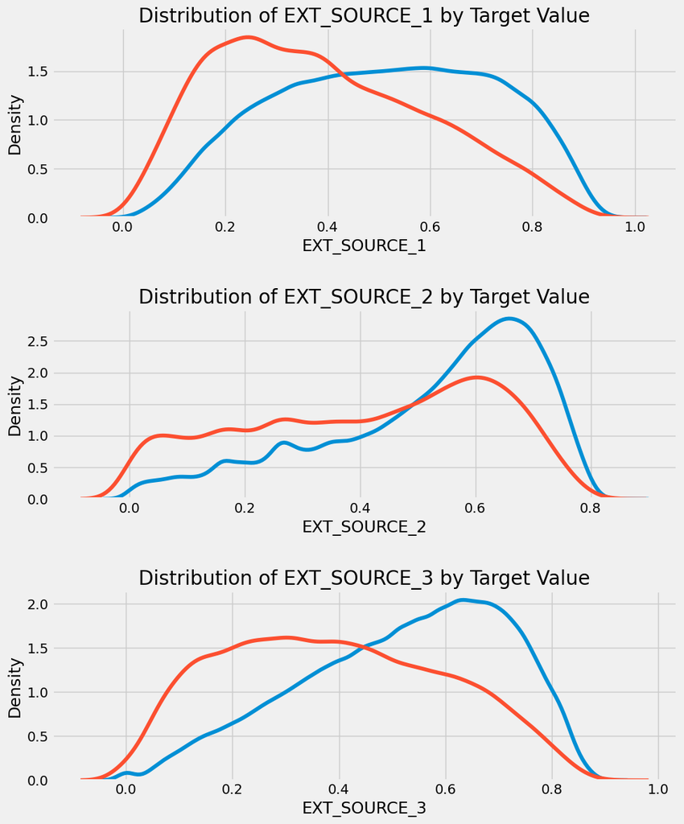

```python
plt.figure(figsize = (10, 12))

# iterate through the sources
for i, source in enumerate(['EXT_SOURCE_1', 'EXT_SOURCE_2', 'EXT_SOURCE_3']):

    # create a new subplot for each source
    plt.subplot(3, 1, i + 1)
    # plot repaid loans
    sns.kdeplot(data.loc[data['TARGET'] == 0, source], label = 'target == 0')
    # plot loans that were not repaid
    sns.kdeplot(data.loc[data['TARGET'] == 1, source], label = 'target == 1')

    # Label the plots
    plt.title('Distribution of %s by Target Value' % source)
    plt.xlabel('%s' % source); plt.ylabel('Density');

plt.tight_layout(h_pad = 2.5)
```

EXT_SOURCE_3 affiche la plus grande différence entre les valeurs de la cible. Nous pouvons clairement voir que cette caractéristique a une certaine relation avec la probabilité qu'un demandeur rembourse un prêt. La relation n'est pas très forte (en fait elles sont toutes considérées comme très faibles, mais ces variables seront tout de même utiles pour un modèle d'apprentissage automatique pour prédire si oui ou non un demandeur remboursera un prêt à temps.

### Pairs plot

En tant que graphique exploratoire final, nous pouvons créer un graphique de paires des variables EXT_SOURCE et de la variable DAYS_BIRTH. Le diagramme de paires est un excellent outil d'exploration car il nous permet de voir les relations entre plusieurs paires de variables ainsi que les distributions de variables uniques. Ici, nous utilisons la bibliothèque de visualisation Seaborn et la fonction PairGrid pour créer un diagramme de paires avec des diagrammes de dispersion sur le triangle supérieur, des histogrammes sur la diagonale et des diagrammes de densité de noyau 2D et des coefficients de corrélation sur le triangle inférieur.

```python
# # Copy the data for plotting
# plot_data = ext_data.drop(columns = ['DAYS_BIRTH']).copy()

# # Add in the age of the client in years
# plot_data['YEARS_BIRTH'] = age_data['YEARS_BIRTH']

# # Drop na values and limit to first 100000 rows
# plot_data = plot_data.dropna().loc[:100000, :]

# # Function to calculate correlation coefficient between two columns
# def corr_func(x, y, **kwargs):
#     r = np.corrcoef(x, y)[0][1]
#     ax = plt.gca()
#     ax.annotate("r = {:.2f}".format(r),
#                 xy=(.2, .8), xycoords=ax.transAxes,
#                 size = 20)

# # Create the pairgrid object
# grid = sns.PairGrid(data = plot_data, diag_sharey=False,
#                     hue = 'TARGET',
#                     vars = [x for x in list(plot_data.columns) if x != 'TARGET'])

# # Upper is a scatter plot
# grid.map_upper(plt.scatter, alpha = 0.2)

# # Diagonal is a histogram
# grid.map_diag(sns.kdeplot)

# # Bottom is density plot
# grid.map_lower(sns.kdeplot, cmap = plt.cm.OrRd_r);

# plt.suptitle('Ext Source and Age Features Pairs Plot', size = 32, y = 1.05)
```

## Feature engineering

```python
def clean_data(train, test):
# Gerer les valeurs abérantes

# Extraire les identifiants

# Extraire les targets

# Supprimer les identifiants de train et test

# Supprimer Target de train

# Extraire le nom des colonnes

# Imputation des Nan

# Ecodage des categories

# Création des features Moyennes, %...

# StandardScaler

# Séparer les données train test split

# retourner 2 dataset propre train et test
```

[output not shown]

## StandardScaler

```python
from sklearn.preprocessing import StandardScaler
cols_to_scale = train.columns.drop('TARGET')
train[cols_to_scale] = StandardScaler().fit_transform(train[cols_to_scale])
test[cols_to_scale] = StandardScaler().fit_transform(test[cols_to_scale])
```

```python
# y_test = test['TARGET']
# X_test = test.drop(columns = 'TARGET')
```

```python
seed = 42
```

```python
# def echantillonage(df_X, df_y):
#     X = df_X.copy()
#     y = df_y.copy()

#     X_train, X_valid, y_train, y_valid = train_test_split(X, y, test_size=0.2, random_state=seed)

#     return X_train, X_valid, y_train, y_valid
```

```python
# df_X = train.drop(columns = 'TARGET')
# df_y = train['TARGET']
# train_set, val_set, train_labels, val_labels = echantillonage(df_X,df_y)
```

```python
# # Afficher la taille des dataset non echantillonnés
# print("train shape", train.shape)
# print("test shape", test.shape)
# print("train_set shape : ",train_set.shape)
# print("val_set shape : ",val_set.shape)
# print("train_labels shape : ",train_labels.shape)
# print("val_labels shape : ",val_labels.shape)
```

### Séparation des dataframes

**Création d'échantillons pour les divers tests d'algorithmes**

```python
# Base de données echantillonnée
X_train, X_train_sample, y_train, y_train_sample = train_test_split(X_train, y_train, test_size=0.2, random_state=seed)
```

```python
# On affiche les dataset
print("X_train_sample", X_train_sample.shape)
print("y_train_sample", y_train_sample.shape)
print("X_valid_sample", X_valid_sample.shape)
print("y_valid_sample", y_valid_sample.shape)
```

[output not shown]

# Modélisation

## Baseline

```python
# Grid Search
```

```python
from sklearn.dummy import DummyClassifier

clf = DummyClassifier(strategy="most_frequent")
clf.fit(X_train_sample, y_train_sample)
y_pred = clf.predict(X_test)
```

```python
def plot_roc_curve(classifiers, X, y, n_splits=5):

    kf = KFold(n_splits=n_splits)
    for name_clf, clf in classifiers.items():
        print(name_clf)
        tprs = []
        aucs = []
        mean_fpr = np.linspace(0, 1, 100)
        for i, (train, test) in enumerate(kf.split(X, y)):

            clf.fit(X.iloc[train, :], y.iloc[train])

            y_pred_grd = clf.predict_proba(X.iloc[test, :])[:, 1]
            fpr, tpr, thresholds = roc_curve(y.iloc[test], y_pred_grd)

            interp_tpr = np.interp(mean_fpr, fpr, tpr)
            interp_tpr[0] = 0.0
            tprs.append(interp_tpr)
            thresholds = auc(fpr, tpr)

            aucs.append(thresholds)

        mean_tpr = np.mean(tprs, axis=0)
        mean_tpr[-1] = 1.0
        mean_auc = auc(mean_fpr, mean_tpr)
        std_auc = np.std(aucs)
        plt.plot(mean_fpr, mean_tpr,
            label=name_clf + r'(AUC = %0.2f $\pm$ %0.2f)' % (mean_auc, std_auc),
            lw=2,
            alpha=.8)

    plt.plot([0, 1], [0, 1], color='navy', lw=2, linestyle='--')
    plt.xlim([0.0, 1.0])
    plt.ylim([0.0, 1.05])
    plt.xlabel('False Positive Rate')
    plt.ylabel('True Positive Rate')
    plt.title('Courbe ROC des différents classifieurs')
    plt.legend(loc="lower right")
    plt.show()
```

```python
# Dictionnaire de classifieurs pour comparer avec
classifieurs = { 'Dummy Classifier': DummyClassifier()}
```

```python
# Permet de comparer plusieurs classieurs
plot_roc_curve(classifieurs, X_train_sample, y_train_sample, n_splits=5)
```

[output not shown]